# Lab 17: Numeric Summaries

## Instructions

Below you will find several empty R code scripts and answer prompts. Your task is to fill in the required code snippets and answer the corresponding questions.

## Cereal Data

Today, we start by looking at a collection of breakfast cereals:

With variables:

- name: name of the specific cereal
- brand: name of the cereal’s manufacturer
- sugar: amount of sugar per serving (g)
- score: healthiness score; 0-100; 100 is the best
- shelf: what shelf the cereal is typically stocked on in the store

Produce a histogram of the sugar variable.

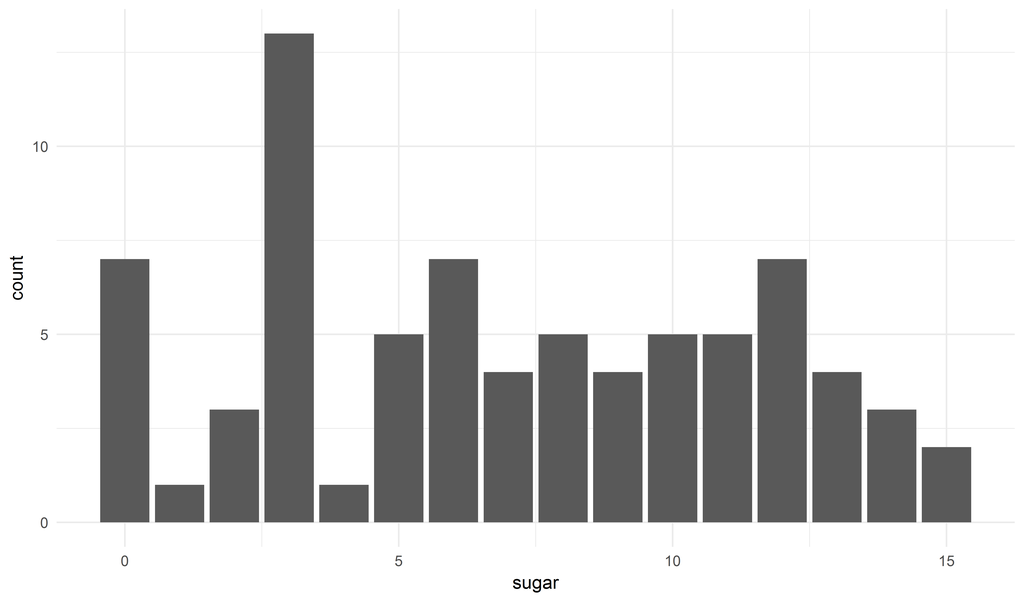

Now, compute the standard deviation of the variable `sugar`:

```
## [1] 4.378656
```

What are the units of this measurement?

**Answer**: grams of sugar per serving

Now, compute the deciles of the variable `score`:

```
##   0%  10%  20%  30%  40%  50%  60%  70%  80%  90% 100%
## 18.0 28.0 31.0 34.5 37.0 40.0 42.0 48.0 53.0 58.0 84.0
```

What is the value of the 30th percentile. Describe what this means in words:

**Answer**: 34.5. This means that about 30% of cereal scored 34.5 or lower, or that about 70% of cereal scored 34.5 or higher.

Produce a boxplot of score and brand.

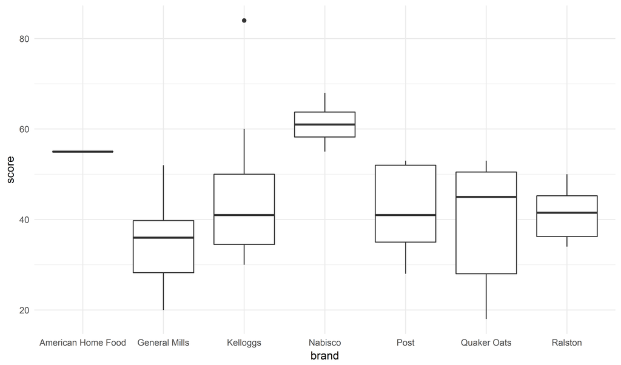

Which brand seems to have the healthiest cereals?

**Answer**: Nabisco seems to have the healthiest overall cereals, but kellogs has the overall most healthy single cereal.

Produce a boxplot of score and shelf.

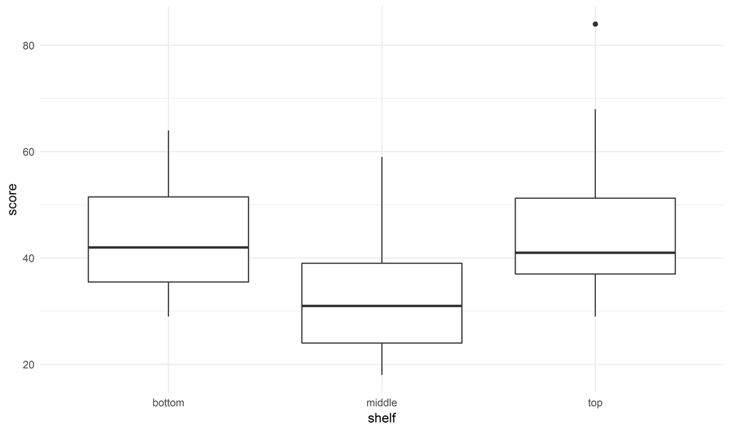

Produce a boxplot of sugar and shelf.

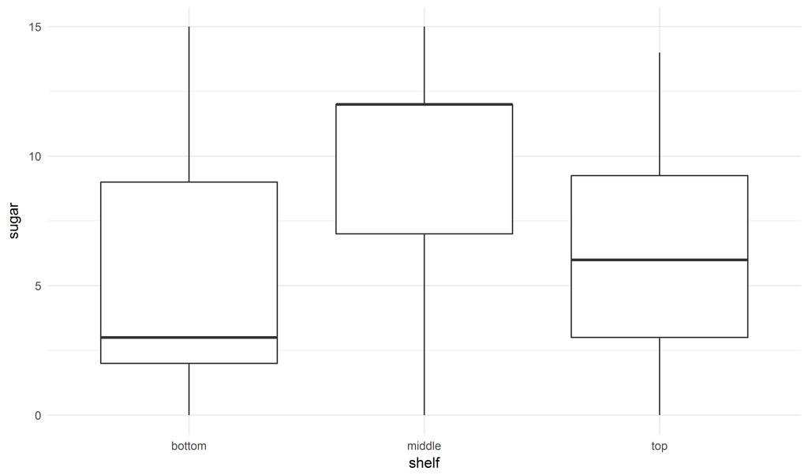

If I want a healthy but reasonably sweet cereal which shelf would be the best to look on?

**Answer**: The top shelf, with the bottom shelf being close behind.

## Tea Reviews

Next, we will take another look at a dataset of tea reviews that I used in a previous lecture:

With variables: - name: the full name of the tea - type: the type of tea. One of: - black - chai - decaf - flavors - green - herbal - masters - matcha - oolong - pu_erh - rooibos - white - score: user rated score; from 0 to 100 - price: estimated price of one cup of tea - num_reviews: total number of online reviews

Draw a scatterplot with num_reviews (x-axis) against score (y-axis) and add a regression line (recall: `geom_smooth(method="lm")`).

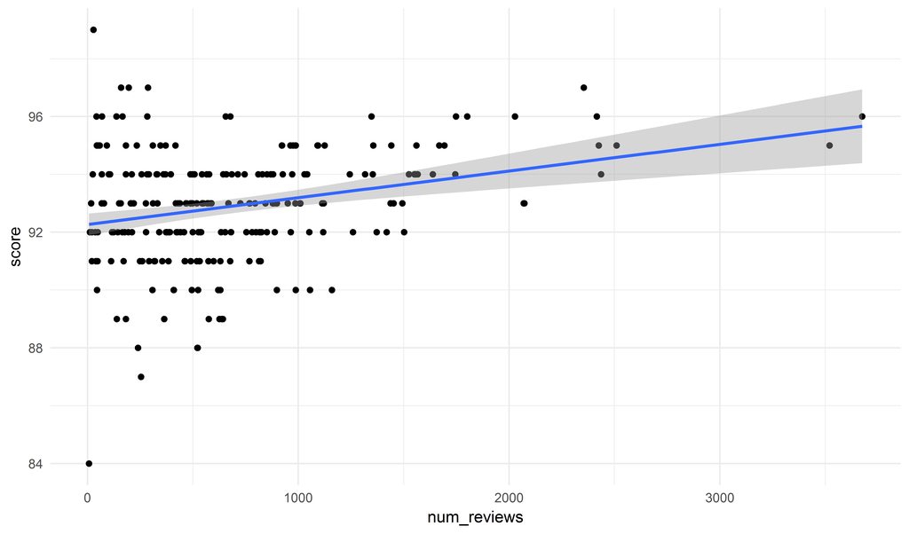

Does the score tend to increase, decrease, or remain the same as the number of reviews increases?

**Answer**: score tends to increase as the number of reviews increases.

Calculate the ventiles of the variable price.

```
##     0%     5%    10%    15%    20%    25%    30%    35%    40%    45%
##   8.00  10.00  10.00  10.00  10.00  10.00  12.00  12.00  12.00  12.00
##    50%    55%    60%    65%    70%    75%    80%    85%    90%    95%
##  13.00  15.00  15.00  17.00  19.00  20.00  30.00  35.35  49.30  86.75
##   100%
## 196.00
```

What is the 80th percentile? Describe it in words, include the units of the problem in your answer.

**Answer**: the 80th percentile is 30.00 dollars per cup of tea. This means that about 80% of the teas cost less than 30.00 dollars per cup, while about 20% cost more than $30.00 per cupo.

Plot the number of reviews (x-axis) against the score variable. Color the points according to price binned into 5 buckets.

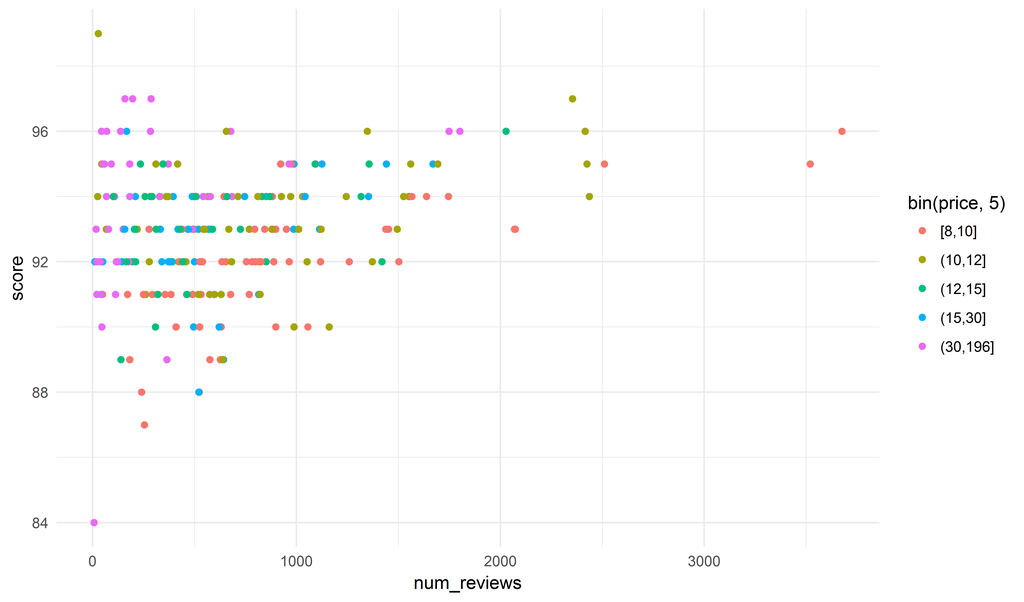

What tends to be true about the number of reviews for the most expensive 20% of teas?

**Answer**: The most expensive 20% of teas have the least number of reviews.

Create a dataset named `white` that consists of only white teas.

Calculate the standard deviation of the price for white teas and the standard deviation of the price for all of the teas.

```
## [1] 13.59444
```

```
## [1] 30.42485
```

Is the variation of the white tea prices smaller, larger, or about the same as the entire dataset?

**Answer**: The variation of the price of white tea is smaller than that of the entire data set.

Summarize the dataset by the type of tea and save the results as a variable named `tea_type`.

Plot the average price (x-axis) against the average score (y-axis) of each type of tea. Make the size of the points proportional to the number of teas in each category and label the points with geom_text_repel and the tea type.

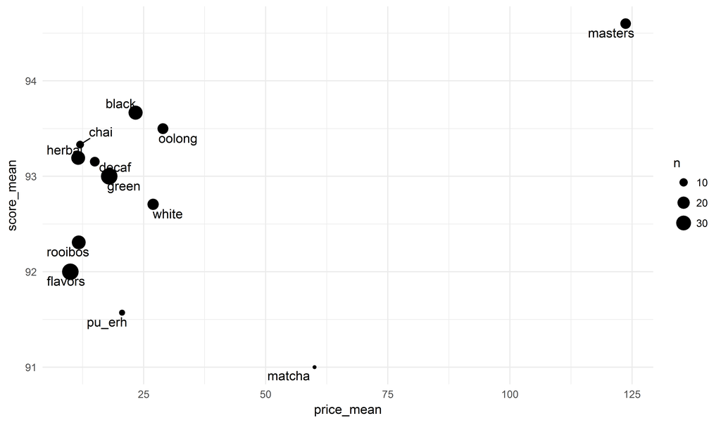

Describe an interesting pattern or set of outliers that you found in the previous plot. This does not need to take more than 1-2 sentences.

**Answer**: The masters teas are far more expensive than any of the other teas. Matcha teas, on the other hand, are the second most expensive tea, but vary the most from the group in the average rating.